# Week 8 Exercise 14

Nosky, Christopher

2/19/2021

> Include all of your answers in a R Markdown report. Here is an example R Markdown report that you can use as a guide.

> Fit a logistic regression model to the binary-classifier-data.csv dataset from the previous assignment.

```r
LogModel.1 <- glm(label~x+y, data = binary_train, family = binomial())
summary(LogModel.1)
```

```
##
## Call:
## glm(formula = label ~ x + y, family = binomial(), data = binary_train)
##
## Deviance Residuals:
##     Min       1Q   Median       3Q      Max
## -1.3658  -1.1672  -0.9614   1.1650   1.4004
##
## Coefficients:
##              Estimate Std. Error z value Pr(>|z|)
## (Intercept)  0.415200   0.143553   2.892 0.003824 **
## x           -0.002376   0.002237  -1.062 0.288036
## y           -0.007953   0.002302  -3.456 0.000549 ***
## ---
## Signif. codes:  0 '***' 0.001 '**' 0.01 '*' 0.05 '.' 0.1 ' ' 1
##
## (Dispersion parameter for binomial family taken to be 1)
##
##     Null deviance: 1382.9  on 997  degrees of freedom
## Residual deviance: 1367.6  on 995  degrees of freedom
## AIC: 1373.6
##
## Number of Fisher Scoring iterations: 4
```

> 1. What is the accuracy of the logistic regression classifier?

```r
LogModel.1.train <- predict(LogModel.1, binary_train, type= 'response')

LogModel.1.test <- predict(LogModel.1, binary_test, type = 'response')

# Model 1 Train confusion matrix
confmatrix.1 <- table(Actual_Value=binary_train$label, Predicted_Value = LogModel.1.train > 0.5)
confmatrix.1
```

```
##             Predicted_Value
## Actual_Value FALSE TRUE
##            0   289  222
##            1   202  285
```

```r
# Model 1 Test confusion matrix
confmatrix.2 <- table(Actual_Value=binary_test$label, Predicted_Value = LogModel.1.test > 0.5)
confmatrix.2
```

```
##             Predicted_Value
## Actual_Value FALSE TRUE
##            0   143  113
##            1    98  146
```

```r
# Model 1 Train acc
(confmatrix.1[[1,1]] + confmatrix.1[[2,2]]) / sum(confmatrix.1)
```

```
## [1] 0.5751503
```

```r
# Model 1 Test acc
(confmatrix.2[[1,1]] + confmatrix.2[[2,2]]) / sum(confmatrix.2)
```

```
## [1] 0.578
```

> 2. How does the accuracy of the logistic regression classifier compare to the nearest neighbors algorithm?
> - First we’ll split the data into training and test sets.

```r
# Split for training / test

set.seed(123) #Getting random sample
dat.d <- sample(1:nrow(binary_data), size=nrow(binary_data)*0.8, replace = FALSE) # Selects 80% of data at random

train.binary <-  binary_data[dat.d,] # 80% training data
test.binary <- binary_data[-dat.d,] # remaining 20% for testing

# Now creating seperate dataframe.
train.binary_labs <- binary_data[dat.d,1]
test.binary_labs <- binary_data[-dat.d, 1]

NROW(train.binary_labs)
```

```
## [1] 1198
```

> - Next we’ll build our Knn model where K=3. As you can see the accuracy comes in at 99.3333%, which is confirmed with the confusion matrix.

```r
bin_knn_3 <- knn(train=train.binary, test=test.binary, cl=train.binary_labs, k=3)

# Let's calculate the proprotion of correct classification for k = 3

bin_acc_3 <- 100 * sum(test.binary_labs == bin_knn_3)/NROW(test.binary_labs) # For knn = 3
bin_acc_3 # Accuracy
```

```
## [1] 99.33333
```

```r
table(bin_knn_3, test.binary_labs) # to check prediction against actual value in tabular form
```

```
##          test.binary_labs
## bin_knn_3   0   1
##         0 158   2
##         1   0 140
```

```r
# ConfusionMatrix
confusionMatrix(table(bin_knn_3, test.binary_labs))
```

```
## Confusion Matrix and Statistics
##
##          test.binary_labs
## bin_knn_3   0   1
##         0 158   2
##         1   0 140
##
##                Accuracy : 0.9933
##                  95% CI : (0.9761, 0.9992)
##     No Information Rate : 0.5267
##     P-Value [Acc > NIR] : <2e-16
##
##                   Kappa : 0.9866
##
##  Mcnemar's Test P-Value : 0.4795
##
##             Sensitivity : 1.0000
##             Specificity : 0.9859
##          Pos Pred Value : 0.9875
##          Neg Pred Value : 1.0000
##              Prevalence : 0.5267
##          Detection Rate : 0.5267
##    Detection Prevalence : 0.5333
##       Balanced Accuracy : 0.9930
##
##        'Positive' Class : 0
##
```

> - Next lets look at different values of K, to see if we can get a better fit. As you can see it appears that we may be able to get a high degree of accuraccy from all of our tested values with K = 18 coming in at 99.66667%

```r
i=1 # Declaration to initiate for loop
bin.k.optm=1 # Declaration to initiate for loop
for (i in 2:25){
  bin.knn.mod <- knn(train=train.binary, test=test.binary, cl=train.binary_labs, k=i)
  bin.k.optm[i] <- 100 * sum(test.binary_labs == bin.knn.mod)/NROW(test.binary_labs)
  k=i
  cat(k,'=', bin.k.optm[i], '\n')
}
```

```
## 2 = 99.33333
## 3 = 99.33333
## 4 = 99
## 5 = 99
## 6 = 99
## 7 = 98.66667
## 8 = 98.66667
## 9 = 99
## 10 = 98.66667
## 11 = 99.33333
## 12 = 99.33333
## 13 = 99.33333
## 14 = 99.33333
## 15 = 99.33333
## 16 = 99
## 17 = 99.33333
## 18 = 99.66667
## 19 = 99
## 20 = 98.66667
## 21 = 99
## 22 = 98.66667
## 23 = 99
## 24 = 99
## 25 = 99.33333
```

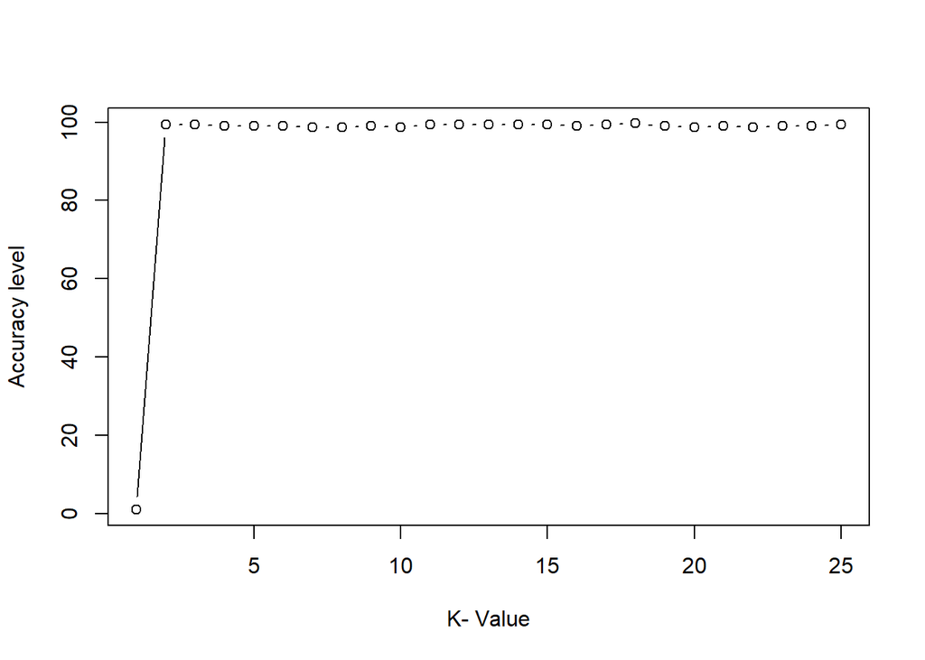

```r
plot(bin.k.optm, type='b', xlab='K- Value', ylab='Accuracy level')
```

> 3. Why is the accuracy of the logistic regression classifier different from that of the nearest neighbors?
> - There are likely a number of reasons that the accuracy is different between the two methods. As the reading points out KNN is a lazy execution, it fits and predicts at the time it is ran. KNN doesn’t tell us which of our predictors are significant, where logistic regression we can approach it in a backwards stepwise method and see the coeficients and pvalues of our predictors to find the variables with the highest significance.